# Recommendation of Coupons In Vehicle

# Feature Importance

Feature importance is another as asking, "which features contributed most to the outcomes of the model and how did they contribute?"

Finding feature importance is different for each machine learning model. One way to find feature importance is to search for "(MODEL NAME) feature importance".

Let's find the feature importance for our Random Forest model..

```python
rf.feature_importances_
```

```
array([0.02104858, 0.04202359, 0.04791148, 0.04603245, 0.07191962,
       0.03108889, 0.02979812, 0.03338547, 0.02620925, 0.00907213,
       0.01745109, 0.00696735, 0.0101571 , 0.01371192, 0.00617924,
       0.00581092, 0.00694687, 0.00751396, 0.01261711, 0.01090278,
       0.01118412, 0.00815478, 0.01326717, 0.00683252, 0.03506371,
       0.04287588, 0.02577859, 0.01627624, 0.03809371, 0.02565481,
       0.02325393, 0.01141919, 0.0117823 , 0.00515322, 0.01068315,
       0.01223933, 0.010589  , 0.00204019, 0.01007892, 0.01014042,
       0.00886775, 0.01242647, 0.01148389, 0.00753944, 0.00168912,
       0.01135143, 0.0042821 , 0.00713437, 0.00049358, 0.00587072,
       0.00383636, 0.01021566, 0.0026831 , 0.00934717, 0.00089875,
       0.00416673, 0.00480615, 0.0047309 , 0.00352611, 0.00553137,
       0.00424492, 0.00880144, 0.00734613, 0.00279343, 0.00225519,
       0.00275216, 0.00665195, 0.01176727, 0.01163615, 0.00437175,
       0.01121091, 0.00938987, 0.00858857])
```

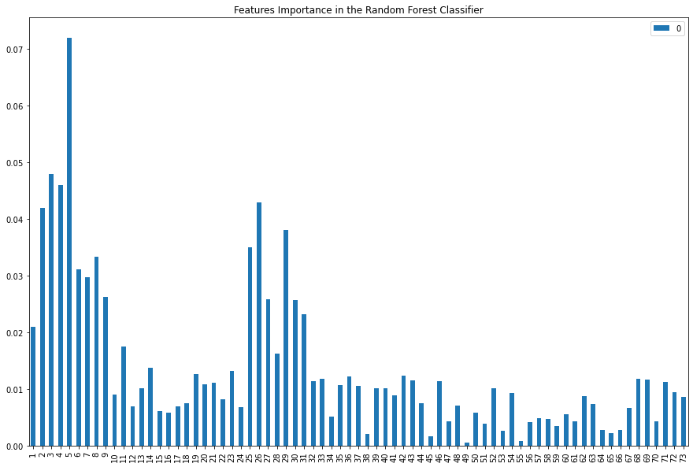

```python
feature_dict = dict(zip(range(1,len(rf.feature_importances_)+1), list(rf.feature_importances_)))
feature_dict

feature_df = pd.DataFrame(feature_dict, index=[0])
feature_df.T.plot.bar(title="Features Importance in the Random Forest Classifier", figsize = (15,10));
```

```python
rf_preds = rf.predict(X_test)
```

```python
print(classification_report(y_test , rf_preds))
```

```
              precision    recall  f1-score   support

           0       0.74      0.63      0.68      1111
           1       0.74      0.83      0.78      1426

    accuracy                           0.74      2537
   macro avg       0.74      0.73      0.73      2537
weighted avg       0.74      0.74      0.74      2537
```

# Conclusion

In the next step, we will train GPU supported models like Neural Networks and Gradient Boosting Machines, tune the hyperparamters with Optuna, stack models to get a better predictive performance, and finally try the autoML tools.